# Practico 2

Oviedo

5/31/2018

## Practico 2: Entregar un Rmd donde se:

- Elija un dataset clasificado de su preferencia y area (domain expertise), aplique un metodo de clustering y/o mixtura de Gaussianas en el mismo.

# Prediciendo manos de Poker

```r
library(class)
library(gmodels)
library(ggplot2)

set.seed(6)
```

```r
# Seeds
# https://archive.ics.uci.edu/ml/datasets/Poker+Hand
# Each record is an example of a hand consisting of five playing cards drawn from a standard deck of 52. Each card is described using two attributes (suit and rank), for a total of 10 predictive attributes. There is one Class attribute that describes the "Poker Hand". The order of cards is important, which is why there are 480 possible Royal Flush hands as compared to 4 (one for each suit - explained in [Web Link]).
data <- read.csv(file="https://archive.ics.uci.edu/ml/machine-learning-databases/poker/poker-hand-testing.data", header=FALSE, sep=",")
```

### Vemos un par de filas

```r
head(data)
```

```
##   V1 V2 V3 V4 V5 V6 V7 V8 V9 V10 V11
## 1  1  1  1 13  2  4  2  3  1  12   0
## 2  3 12  3  2  3 11  4  5  2   5   1
## 3  1  9  4  6  1  4  3  2  3   9   1
## 4  1  4  3 13  2 13  2  1  3   6   1
## 5  3 10  2  7  1  2  2 11  4   9   0
## 6  1  3  4  5  3  4  1 12  4   6   0
```

#### Explicación de las columnas (tomado de la fuente de datos)

1. S1 “Suit of card #1” Ordinal (1-4) representing {Hearts, Spades, Diamonds, Clubs}
2. C1 “Rank of card #1” Numerical (1-13) representing (Ace, 2, 3, … , Queen, King)
3. S2 “Suit of card #2” Ordinal (1-4) representing {Hearts, Spades, Diamonds, Clubs}
4. C2 “Rank of card #2” Numerical (1-13) representing (Ace, 2, 3, … , Queen, King)
5. S3 “Suit of card #3” Ordinal (1-4) representing {Hearts, Spades, Diamonds, Clubs}
6. C3 “Rank of card #3” Numerical (1-13) representing (Ace, 2, 3, … , Queen, King)
7. S4 “Suit of card #4” Ordinal (1-4) representing {Hearts, Spades, Diamonds, Clubs}
8. C4 “Rank of card #4” Numerical (1-13) representing (Ace, 2, 3, … , Queen, King)
9. S5 “Suit of card #5” Ordinal (1-4) representing {Hearts, Spades, Diamonds, Clubs}
10. C5 “Rank of card 5” Numerical (1-13) representing (Ace, 2, 3, … , Queen, King)
11. CLASS “Poker Hand” Ordinal (0-9)

0: Nothing in hand; not a recognized poker hand 1: One pair; one pair of equal ranks within five cards 2: Two pairs; two pairs of equal ranks within five cards 3: Three of a kind; three equal ranks within five cards 4: Straight; five cards, sequentially ranked with no gaps 5: Flush; five cards with the same suit 6: Full house; pair + different rank three of a kind 7: Four of a kind; four equal ranks within five cards 8: Straight flush; straight + flush 9: Royal flush; {Ace, King, Queen, Jack, Ten} + flush

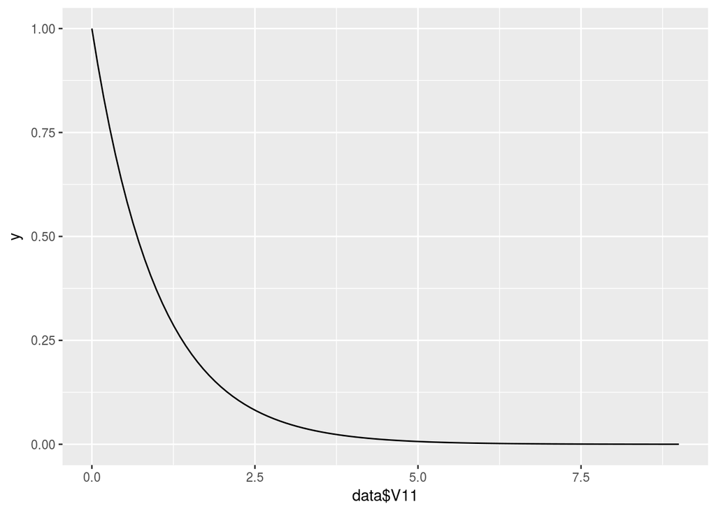

```r
ggplot(data) + stat_function(aes(data$V11),fun=dexp)
```

# Analizamos el resumen de los datos

```r
summary(data)
```

```
##        V1            V2               V3            V4
##  Min.   :1.0   Min.   : 1.000   Min.   :1.0   Min.   : 1.000
##  1st Qu.:2.0   1st Qu.: 4.000   1st Qu.:1.0   1st Qu.: 4.000
##  Median :3.0   Median : 7.000   Median :3.0   Median : 7.000
##  Mean   :2.5   Mean   : 6.998   Mean   :2.5   Mean   : 7.006
##  3rd Qu.:3.0   3rd Qu.:10.000   3rd Qu.:4.0   3rd Qu.:10.000
##  Max.   :4.0   Max.   :13.000   Max.   :4.0   Max.   :13.000
##        V5              V6               V7            V8
##  Min.   :1.000   Min.   : 1.000   Min.   :1.0   Min.   : 1.000
##  1st Qu.:1.000   1st Qu.: 4.000   1st Qu.:2.0   1st Qu.: 4.000
##  Median :3.000   Median : 7.000   Median :3.0   Median : 7.000
##  Mean   :2.501   Mean   : 6.999   Mean   :2.5   Mean   : 7.002
##  3rd Qu.:4.000   3rd Qu.:10.000   3rd Qu.:3.0   3rd Qu.:10.000
##  Max.   :4.000   Max.   :13.000   Max.   :4.0   Max.   :13.000
##        V9             V10              V11
##  Min.   :1.000   Min.   : 1.000   Min.   :0.0000
##  1st Qu.:1.000   1st Qu.: 4.000   1st Qu.:0.0000
##  Median :2.000   Median : 7.000   Median :0.0000
##  Mean   :2.499   Mean   : 6.989   Mean   :0.6169
##  3rd Qu.:4.000   3rd Qu.:10.000   3rd Qu.:1.0000
##  Max.   :4.000   Max.   :13.000   Max.   :9.0000
```

# Separamos los sets para entrenamiento y testeo

```r
# Para entrenar al clasificador, el data set provee los siguientes registros
# https://archive.ics.uci.edu/ml/machine-learning-databases/poker/poker-hand-training-true.data

# Sin embargo, por una cuestión de cantidad vamos a utilizar el 80% de la data y para testear el 20% remanente
nr_rows <- nrow(data)
partition_index = ceiling(nr_rows*0.8)
train_indexes = 1:partition_index
test_indexes = (partition_index + 1):nr_rows

# Pick the labels for the test and train sets
data_train_labels <- data[train_indexes,11]
data_test_labels  <- data[test_indexes,11]
table(data_train_labels)
```

```
## data_train_labels
##      0      1      2      3      4      5      6      7      8      9
## 400786 338291  38039  16854   3077   1611   1162    169      9      2
```

```r
table(data_test_labels)
```

```
## data_test_labels
##      0      1      2      3      4      5      6      7      8      9
## 100423  84207   9583   4267    808    385    262     61      3      1
```

```r
data_train <- data[train_indexes,]
data_test  <- data[test_indexes,]
```

# Escogiendo el mejor K

## Se deben tener en cuenta dos características principales:

- Si K es muy pequeño el modelo será muy sentitivo a puntos que son atípicos o que son ruido (datos corruptos)
- Si K es muy grande, el modelo tiende a asignar siempre a la clase más grande.

Como regla general, entonces, se suele tomar como base la raíz cuadrada de la cantidad de variables, e iterar para ver qué parámetro se ajusta mejor.

```r
best_K = 11^(0.5)
best_K
```

```
## [1] 3.316625
```

Por esto, debido a que la cantidad de variables es 11, se comenzará el analisis tomando el valor 3 para K.

## K = 3

```r
data_test_pred_k3 <- knn(train=data_train, test=data_test, cl=data_train_labels, k=3)
CrossTable(x=data_test_labels, y=data_test_pred_k3, prop.chisq = FALSE)
```

```
##
##
##    Cell Contents
## |-------------------------|
## |                       N |
## |           N / Row Total |
## |           N / Col Total |
## |         N / Table Total |
## |-------------------------|
##
##
## Total Observations in Table:  200000
##
##
##                  | data_test_pred_k3
## data_test_labels |         0 |         1 |         2 |         3 |         4 |         5 |         6 |         7 | Row Total |
## -----------------|-----------|-----------|-----------|-----------|-----------|-----------|-----------|-----------|-----------|
##                0 |     93717 |      6706 |         0 |         0 |         0 |         0 |         0 |         0 |    100423 |
##                  |     0.933 |     0.067 |     0.000 |     0.000 |     0.000 |     0.000 |     0.000 |     0.000 |     0.502 |
##                  |     0.898 |     0.078 |     0.000 |     0.000 |     0.000 |     0.000 |     0.000 |     0.000 |           |
##                  |     0.469 |     0.034 |     0.000 |     0.000 |     0.000 |     0.000 |     0.000 |     0.000 |           |
## -----------------|-----------|-----------|-----------|-----------|-----------|-----------|-----------|-----------|-----------|
##                1 |     10597 |     73049 |       561 |         0 |         0 |         0 |         0 |         0 |     84207 |
##                  |     0.126 |     0.867 |     0.007 |     0.000 |     0.000 |     0.000 |     0.000 |     0.000 |     0.421 |
##                  |     0.102 |     0.845 |     0.121 |     0.000 |     0.000 |     0.000 |     0.000 |     0.000 |           |
##                  |     0.053 |     0.365 |     0.003 |     0.000 |     0.000 |     0.000 |     0.000 |     0.000 |           |
## -----------------|-----------|-----------|-----------|-----------|-----------|-----------|-----------|-----------|-----------|
##                2 |         1 |      6169 |      3258 |       155 |         0 |         0 |         0 |         0 |      9583 |
##                  |     0.000 |     0.644 |     0.340 |     0.016 |     0.000 |     0.000 |     0.000 |     0.000 |     0.048 |
##                  |     0.000 |     0.071 |     0.700 |     0.047 |     0.000 |     0.000 |     0.000 |     0.000 |           |
##                  |     0.000 |     0.031 |     0.016 |     0.001 |     0.000 |     0.000 |     0.000 |     0.000 |           |
## -----------------|-----------|-----------|-----------|-----------|-----------|-----------|-----------|-----------|-----------|
##                3 |         0 |       490 |       814 |      2933 |        30 |         0 |         0 |         0 |      4267 |
##                  |     0.000 |     0.115 |     0.191 |     0.687 |     0.007 |     0.000 |     0.000 |     0.000 |     0.021 |
##                  |     0.000 |     0.006 |     0.175 |     0.889 |     0.044 |     0.000 |     0.000 |     0.000 |           |
##                  |     0.000 |     0.002 |     0.004 |     0.015 |     0.000 |     0.000 |     0.000 |     0.000 |           |
## -----------------|-----------|-----------|-----------|-----------|-----------|-----------|-----------|-----------|-----------|
##                4 |         0 |         0 |        20 |       175 |       613 |         0 |         0 |         0 |       808 |
##                  |     0.000 |     0.000 |     0.025 |     0.217 |     0.759 |     0.000 |     0.000 |     0.000 |     0.004 |
##                  |     0.000 |     0.000 |     0.004 |     0.053 |     0.894 |     0.000 |     0.000 |     0.000 |           |
```

[output cut: 17 more lines]

```
##                8 |         0 |         0 |         0 |         0 |         1 |         1 |         1 |         0 |         3 |
##                  |     0.000 |     0.000 |     0.000 |     0.000 |     0.333 |     0.333 |     0.333 |     0.000 |     0.000 |
##                  |     0.000 |     0.000 |     0.000 |     0.000 |     0.001 |     0.003 |     0.004 |     0.000 |           |
##                  |     0.000 |     0.000 |     0.000 |     0.000 |     0.000 |     0.000 |     0.000 |     0.000 |           |
## -----------------|-----------|-----------|-----------|-----------|-----------|-----------|-----------|-----------|-----------|
##                9 |         0 |         0 |         0 |         0 |         1 |         0 |         0 |         0 |         1 |
##                  |     0.000 |     0.000 |     0.000 |     0.000 |     1.000 |     0.000 |     0.000 |     0.000 |     0.000 |
##                  |     0.000 |     0.000 |     0.000 |     0.000 |     0.001 |     0.000 |     0.000 |     0.000 |           |
##                  |     0.000 |     0.000 |     0.000 |     0.000 |     0.000 |     0.000 |     0.000 |     0.000 |           |
## -----------------|-----------|-----------|-----------|-----------|-----------|-----------|-----------|-----------|-----------|
##     Column Total |    104315 |     86414 |      4655 |      3300 |       686 |       358 |       252 |        20 |    200000 |
##                  |     0.522 |     0.432 |     0.023 |     0.017 |     0.003 |     0.002 |     0.001 |     0.000 |           |
## -----------------|-----------|-----------|-----------|-----------|-----------|-----------|-----------|-----------|-----------|
##
##
```

## K = 5

```r
data_test_pred_k5 <- knn(train=data_train, test=data_test, cl=data_train_labels, k=5)
CrossTable(x=data_test_labels, y=data_test_pred_k5, prop.chisq = FALSE)
```

```
##
##
##    Cell Contents
## |-------------------------|
## |                       N |
## |           N / Row Total |
## |           N / Col Total |
## |         N / Table Total |
## |-------------------------|
##
##
## Total Observations in Table:  200000
##
##
##                  | data_test_pred_k5
## data_test_labels |         0 |         1 |         2 |         3 |         4 |         5 |         6 |         7 | Row Total |
## -----------------|-----------|-----------|-----------|-----------|-----------|-----------|-----------|-----------|-----------|
##                0 |     94519 |      5904 |         0 |         0 |         0 |         0 |         0 |         0 |    100423 |
##                  |     0.941 |     0.059 |     0.000 |     0.000 |     0.000 |     0.000 |     0.000 |     0.000 |     0.502 |
##                  |     0.899 |     0.068 |     0.000 |     0.000 |     0.000 |     0.000 |     0.000 |     0.000 |           |
##                  |     0.473 |     0.030 |     0.000 |     0.000 |     0.000 |     0.000 |     0.000 |     0.000 |           |
## -----------------|-----------|-----------|-----------|-----------|-----------|-----------|-----------|-----------|-----------|
##                1 |     10649 |     73340 |       218 |         0 |         0 |         0 |         0 |         0 |     84207 |
##                  |     0.126 |     0.871 |     0.003 |     0.000 |     0.000 |     0.000 |     0.000 |     0.000 |     0.421 |
##                  |     0.101 |     0.843 |     0.064 |     0.000 |     0.000 |     0.000 |     0.000 |     0.000 |           |
##                  |     0.053 |     0.367 |     0.001 |     0.000 |     0.000 |     0.000 |     0.000 |     0.000 |           |
## -----------------|-----------|-----------|-----------|-----------|-----------|-----------|-----------|-----------|-----------|
##                2 |         2 |      7080 |      2390 |       111 |         0 |         0 |         0 |         0 |      9583 |
##                  |     0.000 |     0.739 |     0.249 |     0.012 |     0.000 |     0.000 |     0.000 |     0.000 |     0.048 |
##                  |     0.000 |     0.081 |     0.699 |     0.036 |     0.000 |     0.000 |     0.000 |     0.000 |           |
##                  |     0.000 |     0.035 |     0.012 |     0.001 |     0.000 |     0.000 |     0.000 |     0.000 |           |
## -----------------|-----------|-----------|-----------|-----------|-----------|-----------|-----------|-----------|-----------|
##                3 |         0 |       723 |       786 |      2737 |        21 |         0 |         0 |         0 |      4267 |
##                  |     0.000 |     0.169 |     0.184 |     0.641 |     0.005 |     0.000 |     0.000 |     0.000 |     0.021 |
##                  |     0.000 |     0.008 |     0.230 |     0.887 |     0.031 |     0.000 |     0.000 |     0.000 |           |
##                  |     0.000 |     0.004 |     0.004 |     0.014 |     0.000 |     0.000 |     0.000 |     0.000 |           |
## -----------------|-----------|-----------|-----------|-----------|-----------|-----------|-----------|-----------|-----------|
##                4 |         0 |         0 |        19 |       182 |       607 |         0 |         0 |         0 |       808 |
##                  |     0.000 |     0.000 |     0.024 |     0.225 |     0.751 |     0.000 |     0.000 |     0.000 |     0.004 |
##                  |     0.000 |     0.000 |     0.006 |     0.059 |     0.882 |     0.000 |     0.000 |     0.000 |           |
```

[output cut: 17 more lines]

```
##                8 |         0 |         0 |         0 |         0 |         0 |         2 |         1 |         0 |         3 |
##                  |     0.000 |     0.000 |     0.000 |     0.000 |     0.000 |     0.667 |     0.333 |     0.000 |     0.000 |
##                  |     0.000 |     0.000 |     0.000 |     0.000 |     0.000 |     0.006 |     0.004 |     0.000 |           |
##                  |     0.000 |     0.000 |     0.000 |     0.000 |     0.000 |     0.000 |     0.000 |     0.000 |           |
## -----------------|-----------|-----------|-----------|-----------|-----------|-----------|-----------|-----------|-----------|
##                9 |         0 |         0 |         0 |         0 |         1 |         0 |         0 |         0 |         1 |
##                  |     0.000 |     0.000 |     0.000 |     0.000 |     1.000 |     0.000 |     0.000 |     0.000 |     0.000 |
##                  |     0.000 |     0.000 |     0.000 |     0.000 |     0.001 |     0.000 |     0.000 |     0.000 |           |
##                  |     0.000 |     0.000 |     0.000 |     0.000 |     0.000 |     0.000 |     0.000 |     0.000 |           |
## -----------------|-----------|-----------|-----------|-----------|-----------|-----------|-----------|-----------|-----------|
##     Column Total |    105170 |     87047 |      3420 |      3085 |       688 |       351 |       224 |        15 |    200000 |
##                  |     0.526 |     0.435 |     0.017 |     0.015 |     0.003 |     0.002 |     0.001 |     0.000 |           |
## -----------------|-----------|-----------|-----------|-----------|-----------|-----------|-----------|-----------|-----------|
##
##
```

## K = 7

```r
data_test_pred_k7 <- knn(train=data_train, test=data_test, cl=data_train_labels, k=7)
CrossTable(x=data_test_labels, y=data_test_pred_k7, prop.chisq = FALSE)
```

```
##
##
##    Cell Contents
## |-------------------------|
## |                       N |
## |           N / Row Total |
## |           N / Col Total |
## |         N / Table Total |
## |-------------------------|
##
##
## Total Observations in Table:  200000
##
##
##                  | data_test_pred_k7
## data_test_labels |         0 |         1 |         2 |         3 |         4 |         5 |         6 |         7 | Row Total |
## -----------------|-----------|-----------|-----------|-----------|-----------|-----------|-----------|-----------|-----------|
##                0 |     94982 |      5441 |         0 |         0 |         0 |         0 |         0 |         0 |    100423 |
##                  |     0.946 |     0.054 |     0.000 |     0.000 |     0.000 |     0.000 |     0.000 |     0.000 |     0.502 |
##                  |     0.896 |     0.062 |     0.000 |     0.000 |     0.000 |     0.000 |     0.000 |     0.000 |           |
##                  |     0.475 |     0.027 |     0.000 |     0.000 |     0.000 |     0.000 |     0.000 |     0.000 |           |
## -----------------|-----------|-----------|-----------|-----------|-----------|-----------|-----------|-----------|-----------|
##                1 |     10970 |     73150 |        87 |         0 |         0 |         0 |         0 |         0 |     84207 |
##                  |     0.130 |     0.869 |     0.001 |     0.000 |     0.000 |     0.000 |     0.000 |     0.000 |     0.421 |
##                  |     0.104 |     0.839 |     0.031 |     0.000 |     0.000 |     0.000 |     0.000 |     0.000 |           |
##                  |     0.055 |     0.366 |     0.000 |     0.000 |     0.000 |     0.000 |     0.000 |     0.000 |           |
## -----------------|-----------|-----------|-----------|-----------|-----------|-----------|-----------|-----------|-----------|
##                2 |         0 |      7664 |      1855 |        64 |         0 |         0 |         0 |         0 |      9583 |
##                  |     0.000 |     0.800 |     0.194 |     0.007 |     0.000 |     0.000 |     0.000 |     0.000 |     0.048 |
##                  |     0.000 |     0.088 |     0.662 |     0.023 |     0.000 |     0.000 |     0.000 |     0.000 |           |
##                  |     0.000 |     0.038 |     0.009 |     0.000 |     0.000 |     0.000 |     0.000 |     0.000 |           |
## -----------------|-----------|-----------|-----------|-----------|-----------|-----------|-----------|-----------|-----------|
##                3 |         0 |       930 |       824 |      2498 |        15 |         0 |         0 |         0 |      4267 |
##                  |     0.000 |     0.218 |     0.193 |     0.585 |     0.004 |     0.000 |     0.000 |     0.000 |     0.021 |
##                  |     0.000 |     0.011 |     0.294 |     0.884 |     0.022 |     0.000 |     0.000 |     0.000 |           |
##                  |     0.000 |     0.005 |     0.004 |     0.012 |     0.000 |     0.000 |     0.000 |     0.000 |           |
## -----------------|-----------|-----------|-----------|-----------|-----------|-----------|-----------|-----------|-----------|
##                4 |         0 |         0 |        21 |       190 |       597 |         0 |         0 |         0 |       808 |
##                  |     0.000 |     0.000 |     0.026 |     0.235 |     0.739 |     0.000 |     0.000 |     0.000 |     0.004 |
##                  |     0.000 |     0.000 |     0.007 |     0.067 |     0.879 |     0.000 |     0.000 |     0.000 |           |
```

[output cut: 17 more lines]

```
##                8 |         0 |         0 |         0 |         0 |         0 |         2 |         1 |         0 |         3 |
##                  |     0.000 |     0.000 |     0.000 |     0.000 |     0.000 |     0.667 |     0.333 |     0.000 |     0.000 |
##                  |     0.000 |     0.000 |     0.000 |     0.000 |     0.000 |     0.006 |     0.005 |     0.000 |           |
##                  |     0.000 |     0.000 |     0.000 |     0.000 |     0.000 |     0.000 |     0.000 |     0.000 |           |
## -----------------|-----------|-----------|-----------|-----------|-----------|-----------|-----------|-----------|-----------|
##                9 |         0 |         0 |         0 |         0 |         1 |         0 |         0 |         0 |         1 |
##                  |     0.000 |     0.000 |     0.000 |     0.000 |     1.000 |     0.000 |     0.000 |     0.000 |     0.000 |
##                  |     0.000 |     0.000 |     0.000 |     0.000 |     0.001 |     0.000 |     0.000 |     0.000 |           |
##                  |     0.000 |     0.000 |     0.000 |     0.000 |     0.000 |     0.000 |     0.000 |     0.000 |           |
## -----------------|-----------|-----------|-----------|-----------|-----------|-----------|-----------|-----------|-----------|
##     Column Total |    105952 |     87185 |      2800 |      2825 |       679 |       336 |       211 |        12 |    200000 |
##                  |     0.530 |     0.436 |     0.014 |     0.014 |     0.003 |     0.002 |     0.001 |     0.000 |           |
## -----------------|-----------|-----------|-----------|-----------|-----------|-----------|-----------|-----------|-----------|
##
##
```

## K = 15

```r
data_test_pred_k15 <- knn(train=data_train, test=data_test, cl=data_train_labels, k=15)
CrossTable(x=data_test_labels, y=data_test_pred_k15, prop.chisq = FALSE)
```

```
##
##
##    Cell Contents
## |-------------------------|
## |                       N |
## |           N / Row Total |
## |           N / Col Total |
## |         N / Table Total |
## |-------------------------|
##
##
## Total Observations in Table:  200000
##
##
##                  | data_test_pred_k15
## data_test_labels |         0 |         1 |         2 |         3 |         4 |         5 |         6 |         7 | Row Total |
## -----------------|-----------|-----------|-----------|-----------|-----------|-----------|-----------|-----------|-----------|
##                0 |     95935 |      4488 |         0 |         0 |         0 |         0 |         0 |         0 |    100423 |
##                  |     0.955 |     0.045 |     0.000 |     0.000 |     0.000 |     0.000 |     0.000 |     0.000 |     0.502 |
##                  |     0.891 |     0.051 |     0.000 |     0.000 |     0.000 |     0.000 |     0.000 |     0.000 |           |
##                  |     0.480 |     0.022 |     0.000 |     0.000 |     0.000 |     0.000 |     0.000 |     0.000 |           |
## -----------------|-----------|-----------|-----------|-----------|-----------|-----------|-----------|-----------|-----------|
##                1 |     11764 |     72434 |         9 |         0 |         0 |         0 |         0 |         0 |     84207 |
##                  |     0.140 |     0.860 |     0.000 |     0.000 |     0.000 |     0.000 |     0.000 |     0.000 |     0.421 |
##                  |     0.109 |     0.829 |     0.006 |     0.000 |     0.000 |     0.000 |     0.000 |     0.000 |           |
##                  |     0.059 |     0.362 |     0.000 |     0.000 |     0.000 |     0.000 |     0.000 |     0.000 |           |
## -----------------|-----------|-----------|-----------|-----------|-----------|-----------|-----------|-----------|-----------|
##                2 |         0 |      8801 |       757 |        25 |         0 |         0 |         0 |         0 |      9583 |
##                  |     0.000 |     0.918 |     0.079 |     0.003 |     0.000 |     0.000 |     0.000 |     0.000 |     0.048 |
##                  |     0.000 |     0.101 |     0.470 |     0.011 |     0.000 |     0.000 |     0.000 |     0.000 |           |
##                  |     0.000 |     0.044 |     0.004 |     0.000 |     0.000 |     0.000 |     0.000 |     0.000 |           |
## -----------------|-----------|-----------|-----------|-----------|-----------|-----------|-----------|-----------|-----------|
##                3 |         0 |      1653 |       791 |      1815 |         8 |         0 |         0 |         0 |      4267 |
##                  |     0.000 |     0.387 |     0.185 |     0.425 |     0.002 |     0.000 |     0.000 |     0.000 |     0.021 |
##                  |     0.000 |     0.019 |     0.491 |     0.816 |     0.012 |     0.000 |     0.000 |     0.000 |           |
##                  |     0.000 |     0.008 |     0.004 |     0.009 |     0.000 |     0.000 |     0.000 |     0.000 |           |
## -----------------|-----------|-----------|-----------|-----------|-----------|-----------|-----------|-----------|-----------|
##                4 |         0 |         0 |        20 |       245 |       543 |         0 |         0 |         0 |       808 |
##                  |     0.000 |     0.000 |     0.025 |     0.303 |     0.672 |     0.000 |     0.000 |     0.000 |     0.004 |
##                  |     0.000 |     0.000 |     0.012 |     0.110 |     0.844 |     0.000 |     0.000 |     0.000 |           |
```

[output cut: 17 more lines]

```
##                8 |         0 |         0 |         0 |         0 |         0 |         0 |         3 |         0 |         3 |
##                  |     0.000 |     0.000 |     0.000 |     0.000 |     0.000 |     0.000 |     1.000 |     0.000 |     0.000 |
##                  |     0.000 |     0.000 |     0.000 |     0.000 |     0.000 |     0.000 |     0.019 |     0.000 |           |
##                  |     0.000 |     0.000 |     0.000 |     0.000 |     0.000 |     0.000 |     0.000 |     0.000 |           |
## -----------------|-----------|-----------|-----------|-----------|-----------|-----------|-----------|-----------|-----------|
##                9 |         0 |         0 |         0 |         0 |         1 |         0 |         0 |         0 |         1 |
##                  |     0.000 |     0.000 |     0.000 |     0.000 |     1.000 |     0.000 |     0.000 |     0.000 |     0.000 |
##                  |     0.000 |     0.000 |     0.000 |     0.000 |     0.002 |     0.000 |     0.000 |     0.000 |           |
##                  |     0.000 |     0.000 |     0.000 |     0.000 |     0.000 |     0.000 |     0.000 |     0.000 |           |
## -----------------|-----------|-----------|-----------|-----------|-----------|-----------|-----------|-----------|-----------|
##     Column Total |    107699 |     87378 |      1611 |      2223 |       643 |       287 |       158 |         1 |    200000 |
##                  |     0.538 |     0.437 |     0.008 |     0.011 |     0.003 |     0.001 |     0.001 |     0.000 |           |
## -----------------|-----------|-----------|-----------|-----------|-----------|-----------|-----------|-----------|-----------|
##
##
```

# Conclusión

Vemos después de todo esto, que para valores de K entre 5 y 15, los resultados se asemejan bastasnte.